# Session 2: Intro to frequentist models in R

**Practice example 4:** Test the assumptions of normality for the model in practice 3 (i.e., model without an interactive term). Then, find the appropriate approach to deal with any assumptions that are not met.

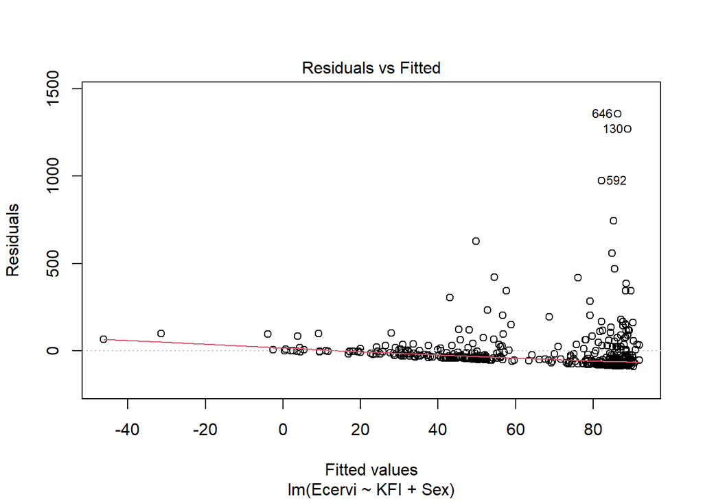

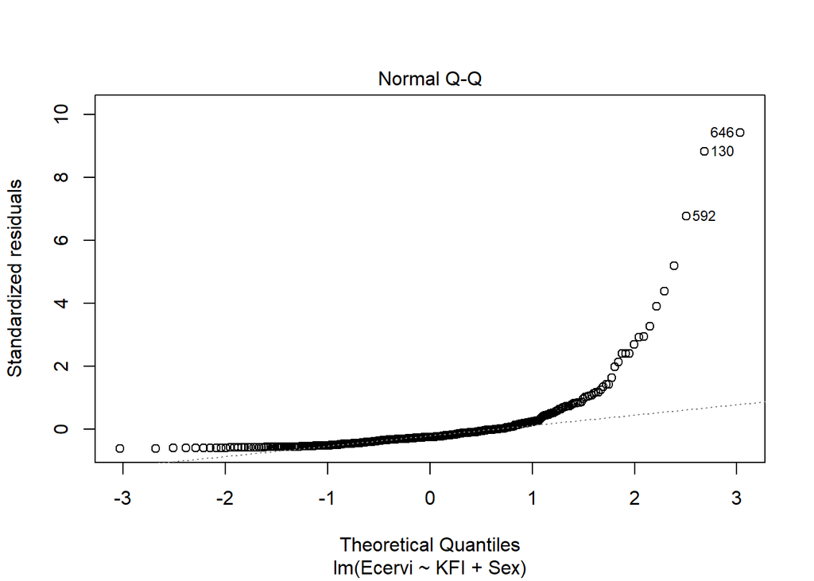

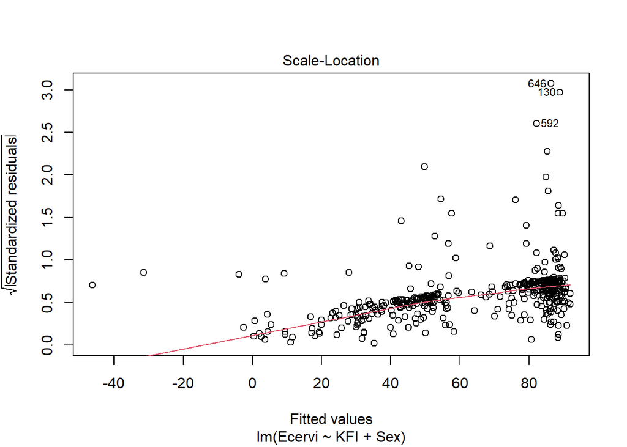

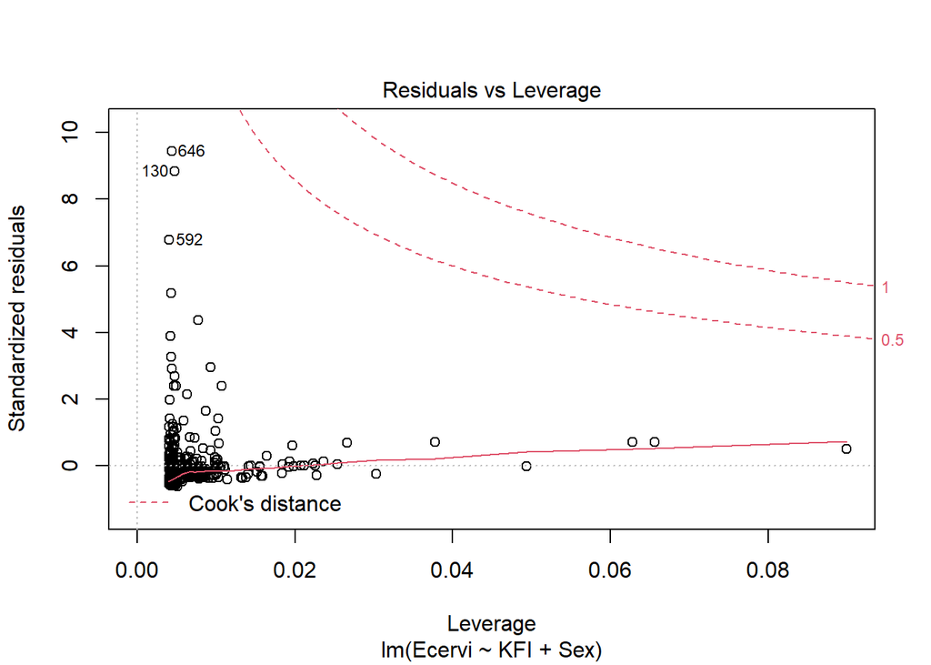

```r
ec2 <- lm(Ecervi ~ KFI + Sex, data = subset(deer, Ecervi > 0))
plot(ec2)
```

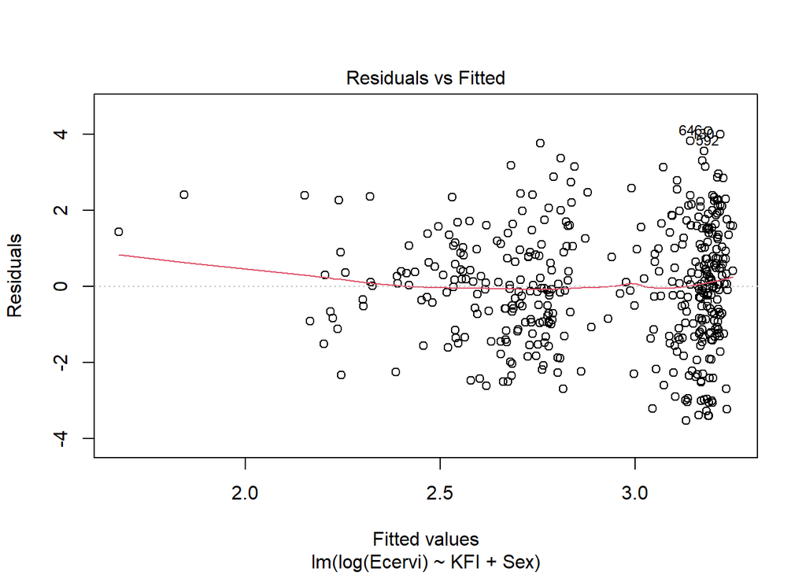

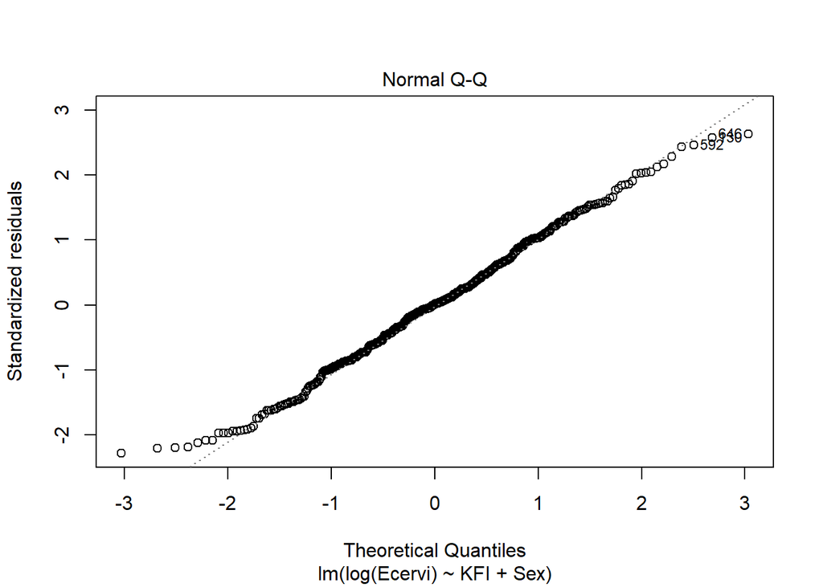

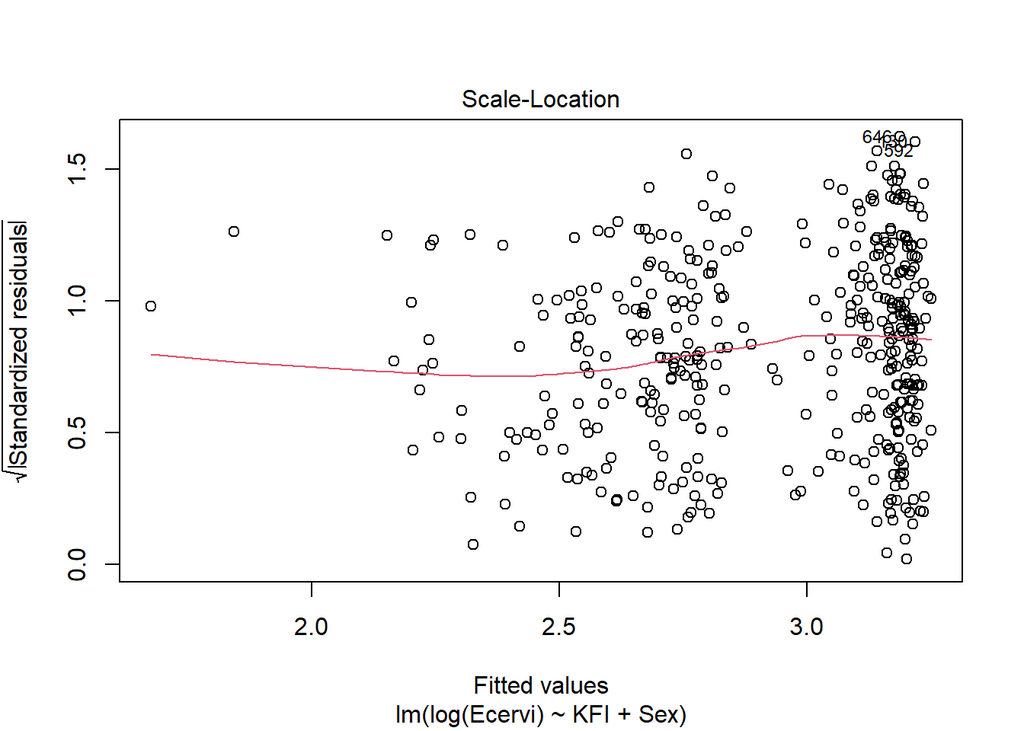

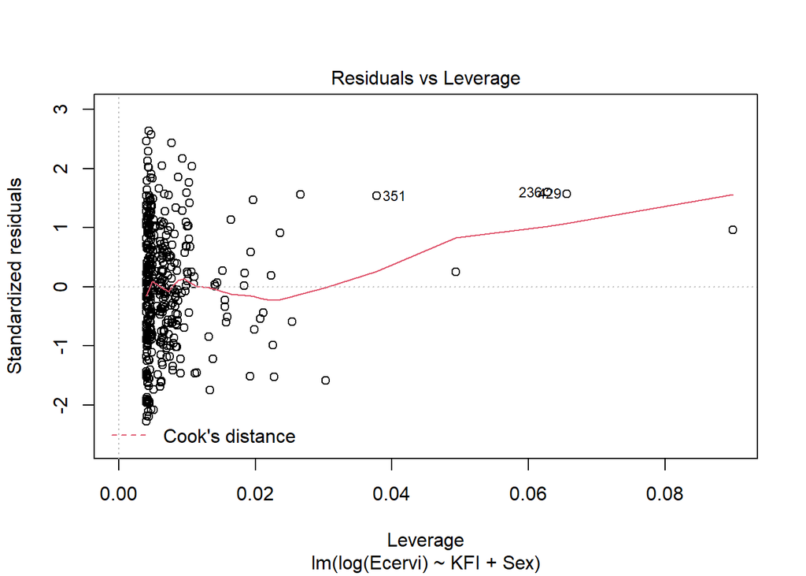

```r
ec3 <- lm(log(Ecervi) ~ KFI  + Sex, data = subset(deer, Ecervi > 0))
plot(ec3)
```

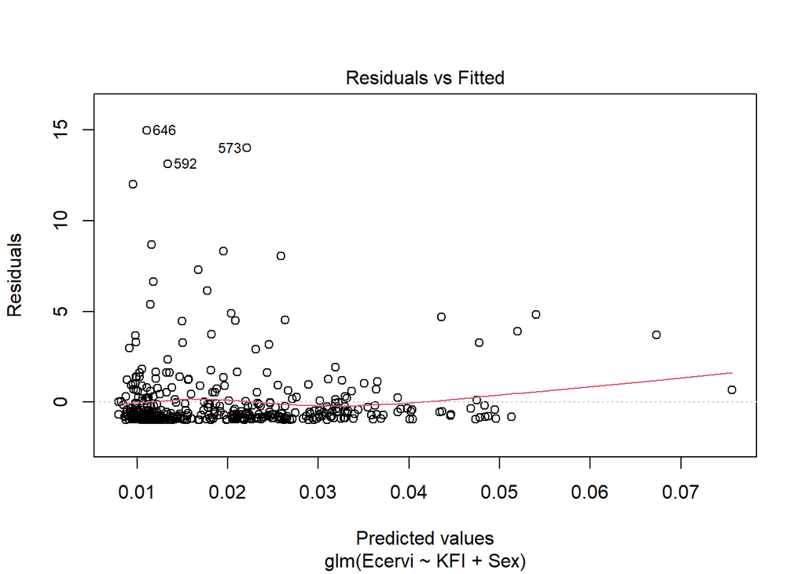

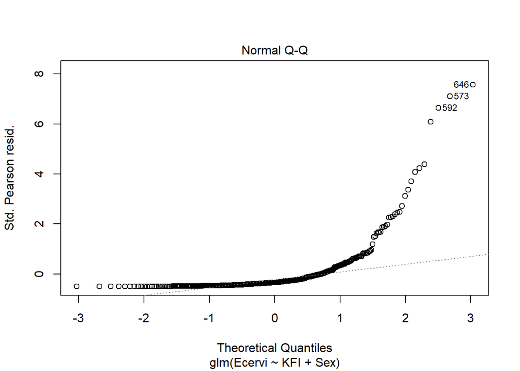

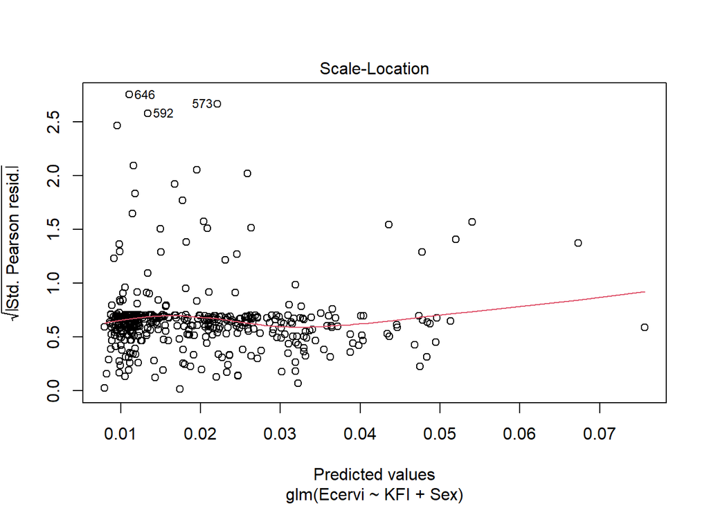

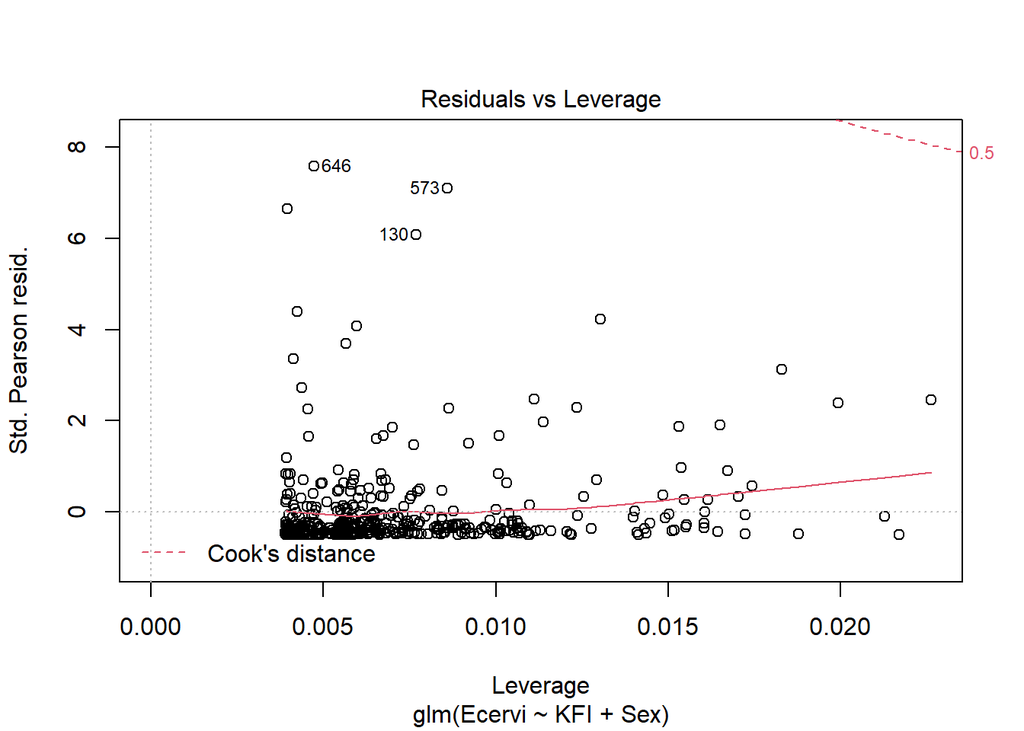

```r
ec4 <- glm(Ecervi ~ KFI + Sex, family = Gamma, data = subset(deer, Ecervi > 0))
plot(ec4)
```

### 2. Model selection

Here, I will outline the general procedure for model selection in two parts: selecting the appropriate probability distribution and selecting variables in your model.

#### Select the probability distribution**

1. Based on first principles

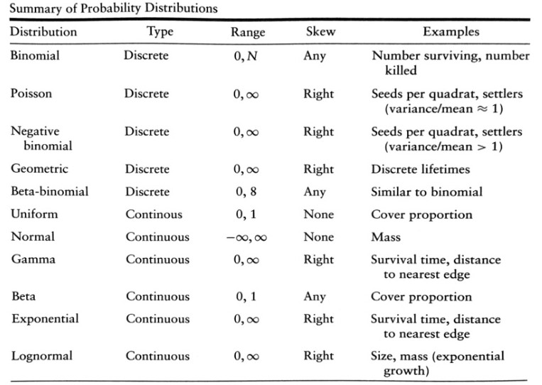

Source: B. Bolker (2008) Ecological Models and Data in R, Princeton University Press, Princeton, New Jersey, USA

2. Based on analysis of data

We could also select the appropriate probability distribution from analyzing our data. To recap, we ran four models to evaluate whether mean density of brown hares changes linearly with year. We can use Akaike Information Criteria to rank our candidate models:

$$AIC_{model} = 2k - 2LL$$
where *k* is the number of parameters in the model and *LL* is the log likelihood of the model. AIC decreases with increasing model fit (*LL*) but penalizes for the number of parameters. The lower the AIC, the better the model.

```r
dens7 <- lm(mean.density ~ year, data = hares.arable)
dens10 <- glm(log(mean.density) ~ year, family = gaussian, data = hares.arable)
dens11 <- glm(mean.density ~ year, family = gaussian(link = "log"), data = hares)
dens12 <- glm(mean.density ~ year, family = Gamma(link = "log"), data = hares)

ICtab(dens7, dens10, dens11, dens12, base = T)
```

```
##        AIC    dAIC   df
## dens10 1229.8    0.0 3
## dens7  2759.1 1529.3 3
## dens12 3391.6 2161.8 3
## dens11 3738.4 2508.6 3
```

The common rule would be to choose the most parsimonious model within 2 dAIC of the winning model.

**Note:** If multiple models fall witin 2 dAIC of the winning model, you can choose to do something referred to as “model averaging”. Model averaging is not ideal for model with different probability distributions. It would be better for averaging multiple winning models, such a linear and quadratic function since the model falls somewhere between those functions. The *bbmle::ICtab()* function has an argument for computing IC weights that allows for model averaging. For more information on model averaging, see Anderson and Burham 2002.

#### Selecting variables

For selecting variables in your model, you can do model selection in two ways: Akaike Information Criteria (AIC) for competing models or likelihood ratio test (LRT) of nested models.

1. AIC analyses of competing models

Here, we might evaluate whether infection intensity of *Elaphostrongylus cervi* parasites in red deer correlated better with length of the animal (LCT) or kidney fat index (KFI).

```r
ec5 <- lm(log(Ecervi) ~ KFI, data = subset(deer, Ecervi > 0))
ec6 <- lm(log(Ecervi) ~ LCT, data = subset(deer, Ecervi > 0))

ICtab(ec5, ec6)
```

```
##     dAIC  df
## ec5   0.0 3
## ec6 451.1 3
```

2. LRT and “marginal hypothesis testing” of a saturated model.

For nested models, we may want to use marginal null hypothesis testing of a saturated model to determine significant effects. For example, we might want to evaluate whether Bay Checkerspot caterpillars reared on two host plant (i.e., Indian paintbrush and English Plantain) that were either sprayed or not sprayed with herbicide treatment affected their mass.

```r
herb <- read.csv(here::here("Session 2", "Data", "HerbicideCaterpillars.csv"))

sat_mod <- glm(Mass ~ Host + Treat + Host:Treat, family=gaussian, data = herb)
Anova(sat_mod)
```

```
## Analysis of Deviance Table (Type II tests)
##
## Response: Mass
##            LR Chisq Df Pr(>Chisq)
## Host        155.777  1    < 2e-16 ***
## Treat         6.200  1    0.01278 *
## Host:Treat    0.168  1    0.68177
## ---
## Signif. codes:  0 '***' 0.001 '**' 0.01 '*' 0.05 '.' 0.1 ' ' 1
```

```r
add_mod <- glm(Mass ~ Host + Treat, family=gaussian, data = herb)
host_mod <- glm(Mass ~ Host, family=gaussian, data = herb)
treat_mod <- glm(Mass ~ Treat, family=gaussian, data = herb)

lrtest(sat_mod, add_mod)
```

```
## Likelihood ratio test
##
## Model 1: Mass ~ Host + Treat + Host:Treat
## Model 2: Mass ~ Host + Treat
##   #Df  LogLik Df  Chisq Pr(>Chisq)
## 1   5 -537.25
## 2   4 -537.33 -1 0.1705     0.6797
```

```r
lrtest(add_mod, host_mod)
```

```
## Likelihood ratio test
##
## Model 1: Mass ~ Host + Treat
## Model 2: Mass ~ Host
##   #Df  LogLik Df  Chisq Pr(>Chisq)
## 1   4 -537.33
## 2   3 -540.44 -1 6.2162    0.01266 *
## ---
## Signif. codes:  0 '***' 0.001 '**' 0.01 '*' 0.05 '.' 0.1 ' ' 1
```

```r
lrtest(add_mod, treat_mod)
```

```
## Likelihood ratio test
##
## Model 1: Mass ~ Host + Treat
## Model 2: Mass ~ Treat
##   #Df  LogLik Df  Chisq Pr(>Chisq)
## 1   4 -537.33
## 2   3 -600.07 -1 125.48  < 2.2e-16 ***
## ---
## Signif. codes:  0 '***' 0.001 '**' 0.01 '*' 0.05 '.' 0.1 ' ' 1
```

### 3. Intro to generalized linear models

Generalized linear models (GLMs) connect a mean of the response to its predictors in a linear way through *link functions*. Therefore, it produces coefficients of a linear relationship on the link function scale. Instead of transforming data to fit a normal distribution, such as the log transformation

$$\mu_{ln(y)} = \beta_{0} + \beta_{1}x_{1} + ...$$
$$ln(y_{i}) = \beta_{0} + \beta_{1}x_{i} + ...$$

GLMs allows data to follow alternative error distributions, such as a Poisson error distribution on a natural log link function scale:

$$ln(\mu_{y}) = \beta_{0} + \beta_{1}x_{1} + ...$$

#### Binomial distribution

Here, we will use generalized linear models to estimate a response that is binomially-distributed. A binomial response can either be at the individual-level (i.e., presence/absence) or at the group-level (e.g., k events and N trials).

We can run a logit-link GLM to estimate the probability of diapausing conditioned on survival as a function of photoperiod, as follows:

```r
diap <- read.csv(here::here("Session 2", "Data", "Diapausing_example.csv"))
head(diap)
```

```
##   Treatment    Sex Surv Diapause
## 1      11.5 female    1        1
## 2      11.5   male    1        1
## 3      11.5   male    0       NA
## 4      12.5 female    1        1
## 5      12.5 female    1        1
## 6      12.5 female    1        1
```

```r
pd1 <- glm(Diapause ~ Treatment, family = binomial, data = subset(diap, Sex == "female"))
summary(pd1)
```

```
##
## Call:
## glm(formula = Diapause ~ Treatment, family = binomial, data = subset(diap,
##     Sex == "female"))
##
## Deviance Residuals:
##      Min        1Q    Median        3Q       Max
## -2.66078   0.00913   0.08165   0.24268   1.56334
##
## Coefficients:
##             Estimate Std. Error z value Pr(>|z|)
## (Intercept)  60.4946     9.8336   6.152 7.66e-10 ***
## Treatment    -4.3834     0.7154  -6.127 8.93e-10 ***
## ---
## Signif. codes:  0 '***' 0.001 '**' 0.01 '*' 0.05 '.' 0.1 ' ' 1
##
## (Dispersion parameter for binomial family taken to be 1)
##
##     Null deviance: 216.53  on 211  degrees of freedom
## Residual deviance: 112.04  on 210  degrees of freedom
##   (15 observations deleted due to missingness)
## AIC: 116.04
##
## Number of Fisher Scoring iterations: 7
```

```r
Anova(pd1)
```

```
## Analysis of Deviance Table (Type II tests)
##
## Response: Diapause
##           LR Chisq Df Pr(>Chisq)
## Treatment   104.49  1  < 2.2e-16 ***
## ---
## Signif. codes:  0 '***' 0.001 '**' 0.01 '*' 0.05 '.' 0.1 ' ' 1
```

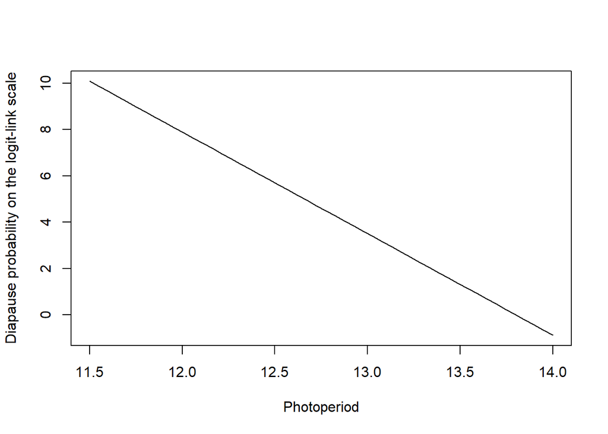

```r
light.vals <- seq(min(diap$Treatment), max(diap$Treatment), length.out = 50)
pd.logit <- coef(pd1)[1] + coef(pd1)[2]*light.vals
pd.pred <- exp(coef(pd1)[1] + coef(pd1)[2]*light.vals)/(1 + exp(coef(pd1)[1] + coef(pd1)[2]*light.vals)) # manual back-transformation

plot(light.vals, pd.logit, type = "l", ylab = "Diapause probability on the logit-link scale", xlab = "Photoperiod")
```

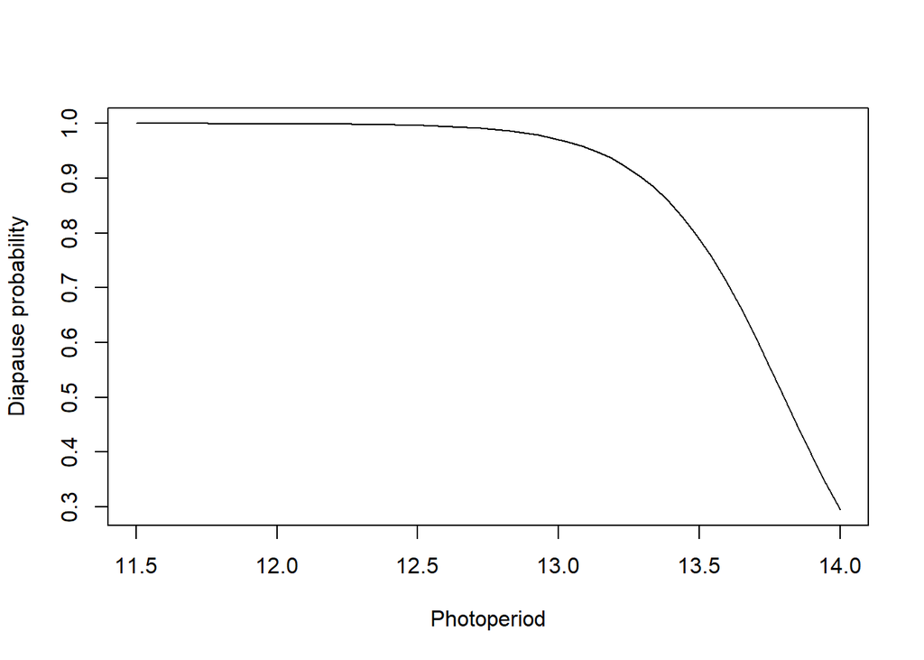

```r
plot(light.vals, plogis(pd.logit), type = "l", ylab = "Diapause probability", xlab = "Photoperiod")
```

First, the summary output includes two more outputs for a GLM: * *Null deviance:* is the 2(LL(Saturated Model) - LL(Null Model)), where the saturated model assumes each data point has its own parameter (*n* parameters) and the null assumes one parameter for all data (1 parameter). * *Residual deviance:* is the 2(LL(Saturated Model - LL(Proposed Model)) and refers the goodness-of-fit of the proposed model, where your data can be explained by *p* parameters and an intercept term.

To compare your null with the proposed, you can calculate the chi-squared value $\chi^2 = null deviance - residual deviance$ and the degrees of freedom $df Proposed - df Null$.

For our second example, we will be using data from an overwintering experiment to estimate the overwinter survival of diapausing pupa of the mustard white butterfly. Each bug dorm had a fall count of diapausing pupa (*N*, trials) and a spring count of the number of emerging butterflies (*k*, events).

We can run an intercept-only logit-link GLM to estimate the overwinter survival of the mustard white butterfly, as follows:

```r
surv <- read.csv(here::here("Session 2", "Data", "OverwinterSurv_example.csv"))
head(surv)
```

```
##   Dorm Fall.count Spring.count
## 1    1          3            1
## 2    3         20            0
## 3    6          8            2
## 4    7          2            0
## 5   11         11            0
## 6   13         11            2
```

```r
ws1 <- glm(cbind(Spring.count, Fall.count - Spring.count) ~ 1, family = binomial, data = surv)
summary(ws1)
```

```
##
## Call:
## glm(formula = cbind(Spring.count, Fall.count - Spring.count) ~
##     1, family = binomial, data = surv)
##
## Deviance Residuals:
##     Min       1Q   Median       3Q      Max
## -2.3610  -1.0870  -0.6373   0.9063   1.9614
##
## Coefficients:
##             Estimate Std. Error z value Pr(>|z|)
## (Intercept)   -1.900      0.268  -7.089 1.35e-12 ***
## ---
## Signif. codes:  0 '***' 0.001 '**' 0.01 '*' 0.05 '.' 0.1 ' ' 1
##
## (Dispersion parameter for binomial family taken to be 1)
##
##     Null deviance: 28.474  on 19  degrees of freedom
## Residual deviance: 28.474  on 19  degrees of freedom
## AIC: 48.119
##
## Number of Fisher Scoring iterations: 5
```

```r
plogis(coef(ws1)) # 13% probability of surviving the winter
```

```
## (Intercept)
##   0.1300813
```

**Practice example 5:** Using the deer data, run a logit-link GLM to estimate the probability that a red deer will have a parasite given its kidney fat index (KFI) and sex.

```r
deer$P.Ecervi <- deer$Ecervi
deer$P.Ecervi[deer$P.Ecervi > 0] <- 1

pec1 <- glm(P.Ecervi ~ KFI*Sex, family = binomial, data = deer)
```

#### Poisson distribution

Here, we will be exploring running log-link GLMs using the Poisson error distribution. Here, we have counts of wolves in each year from 1982 to 2012 across five US states.

```r
wolves <- read.csv(here::here("Session 2", "Data", "NRMwolves.csv"))
```

First, we will evaluate whether the total number of wolves has changed over a 10-year period from 1994-2003.

```r
with(wolves[13:22,], plot(year, num.wolves))

wv10a <- glm(num.wolves ~ year, family = poisson(link = "identity"), data = wolves[13:22,])
coef(wv10a) # year is the change in the # of wolves per year
```

```
##   (Intercept)          year
## -141848.51720      71.15512
```

```r
wv10b <- glm(num.wolves ~ year, family = poisson(link = "log"), data = wolves[13:22,])
exp(coef(wv10b)) # slope is the population growth rate
```

```
##   (Intercept)          year
## 4.426576e-212  1.279324e+00
```

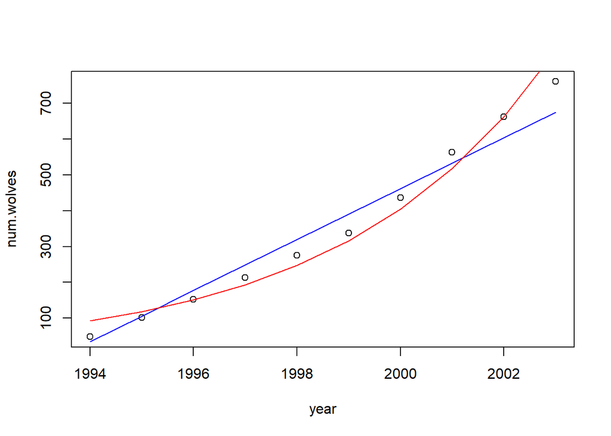

```r
with(wolves[13:22,], plot(year, num.wolves))
points(1994:2003, coef(wv10a)[1] + coef(wv10a)[2]*1994:2003, type = "l", col = "blue") # linear growth
points(1994:2003, exp(coef(wv10b)[1] + coef(wv10b)[2]*1994:2003), type = "l", col = "red") # unlimited expontential growth
```

Second, we will evaluate whether the total number of wolves has changed over the full 30-year period from 1983 to 2012.

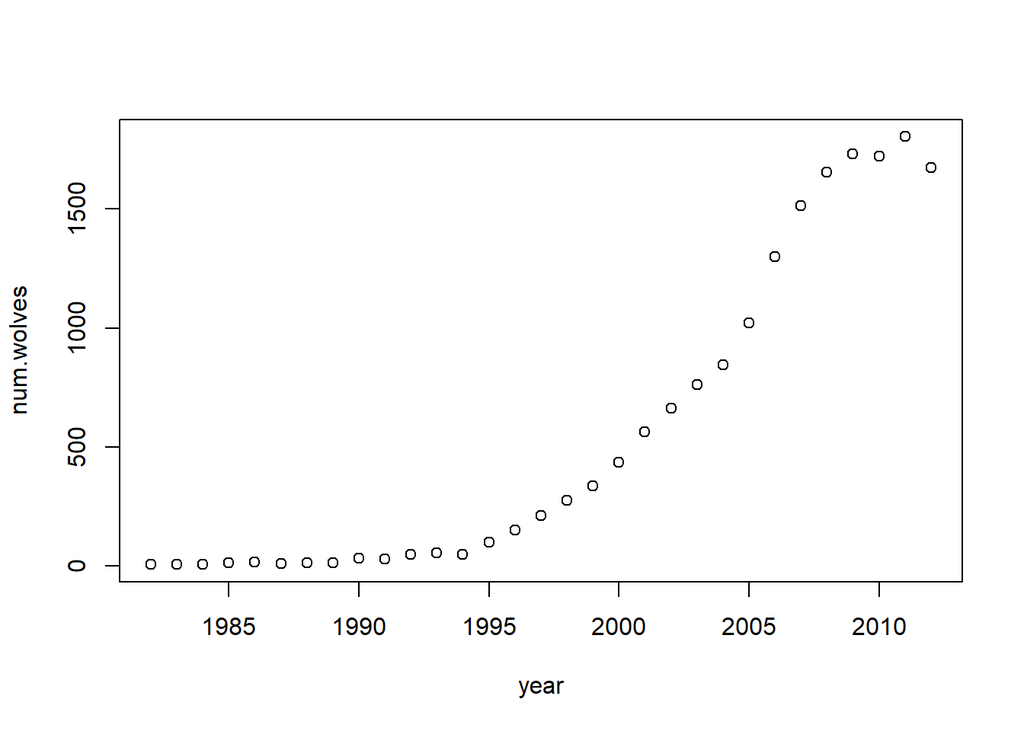

```r
with(wolves, plot(year, num.wolves))
```

```r
wv30a <- glm(num.wolves ~ year, family = poisson(link = "log"), data = wolves[2:31,]) # unlimited exp growth
coef(wv30a)
```

```
##  (Intercept)         year
## -318.2374555    0.1620725
```

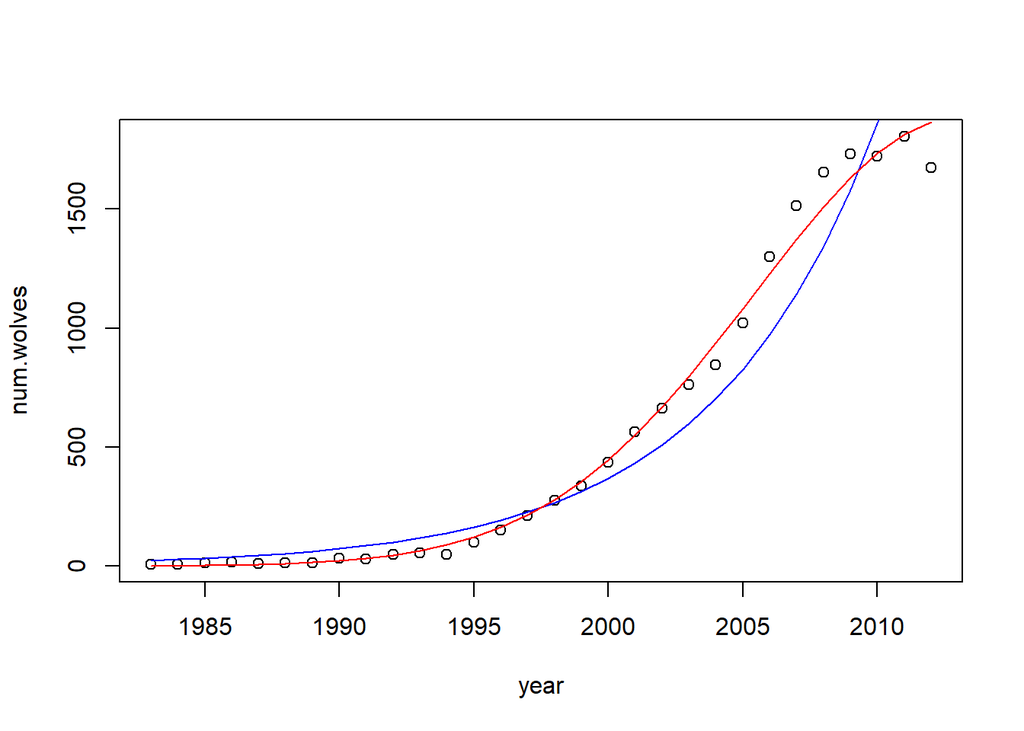

```r
wv30b <- glm(num.wolves ~ year + I(year*year), family = poisson(link = "log"), data = wolves[2:31,]) # quadratic function model

with(wolves[2:31,], plot(year, num.wolves))
points(1983:2012, exp(coef(wv30a)[1] + coef(wv30a)[2]*1983:2012), type = "l", col = "blue")
points(1983:2012, exp(coef(wv30b)[1] + coef(wv30b)[2]*1983:2012 + coef(wv30b)[3]*1983:2012*1983:2012), type = "l", col = "red")
```

**Practice example 6:**

### 4. Common issues with count data

Here, we will cover how to deal with three common issues that you may encounter with Poisson-distributed data: (1) when counts should be represented as rates, (2) when count data are over- or under-dispersed for the Poisson distribution variance, and (3) when count data are zero inflated.

#### … when counts should be rates

A common issue in ecology is when each observtion of count data are not always equally in represented. For example, you may find yourself in a situation where each observation is collected over different lengths of time or you count a number out of a total number.

Here, we will use the Audubon Christmas bird count 2013 data on Northern Flickers across New England. Since observation periods differ, we want to model our counts are rates (# per hour of observation).

```r
flickers <- read.csv(here::here("Session 2", "Data", "NE_flickers.csv"))
head(flickers)
```

```
##   Code                       Name Latitude Longitude  hours Count
## 1 CTBA                Barkhamsted  41.9123  -72.9884  72.50     0
## 2 CTEW Edwin Way Teale Trail Wood  41.7966  -71.9274  48.50     0
## 3 CTGS         Greenwich-Stamford  41.0826  -73.6138 182.50    53
## 4 CTHA                   Hartford  41.7660  -72.6727 198.00     0
## 5 CTLH           Litchfield Hills  41.7703  -73.2724  69.95     0
## 6 CTLS           Lakeville-Sharon  41.9449  -73.4399  49.50     0
```

```r
nf1 <- glm(Count ~ 1, offset = log(hours), family = poisson, data = flickers)
summary(nf1)
```

```
##
## Call:
## glm(formula = Count ~ 1, family = poisson, data = flickers, offset = log(hours))
##
## Deviance Residuals:
##    Min      1Q  Median      3Q     Max
## -5.375  -3.283  -2.691  -1.757  11.576
##
## Coefficients:
##             Estimate Std. Error z value Pr(>|z|)
## (Intercept) -2.61801    0.04089  -64.02   <2e-16 ***
## ---
## Signif. codes:  0 '***' 0.001 '**' 0.01 '*' 0.05 '.' 0.1 ' ' 1
##
## (Dispersion parameter for poisson family taken to be 1)
##
##     Null deviance: 1567.4  on 101  degrees of freedom
## Residual deviance: 1567.4  on 101  degrees of freedom
## AIC: 1681.8
##
## Number of Fisher Scoring iterations: 6
```

```r
exp(coef(nf1)) # 0.07 birds per hour
```

```
## (Intercept)
##  0.07294809
```

We can also use offsets for running a process error model for evaluating population dynamics, where the previous time step offsets the counts in the next step. Therefore, you get an estimated growth rate for each time step of the series.

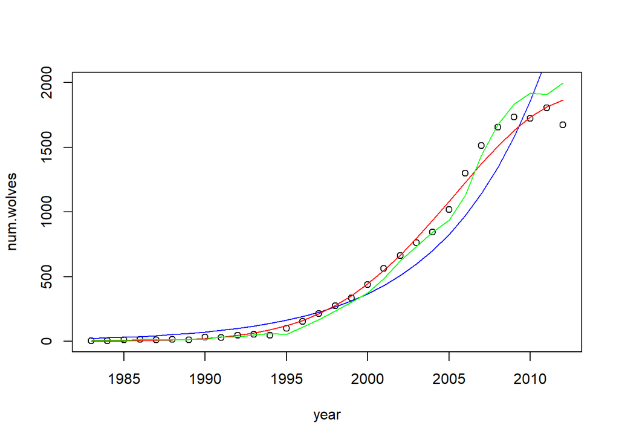

```r
wv30c <- glm(num.wolves[2:31] ~ 1, offset = log(num.wolves[1:30]), family = poisson(link = "log"), data = wolves)

with(wolves[2:31,], plot(year, num.wolves, ylim = c(0, 2000)))
points(1983:2012, exp(coef(wv30a)[1] + coef(wv30a)[2]*1983:2012), type = "l", col = "blue") # observation error
points(1983:2012, exp(coef(wv30b)[1] + coef(wv30b)[2]*1983:2012 + coef(wv30b)[3]*1983:2012*1983:2012), type = "l", col = "red")
points(1983:2012, predict(wv30c, type = "response"), type = "l", col = "green") # process error
```

**Practice example 7:** Similarly, we could also model the brown hare counts per area as a Poisson offset instead of mean.density using the normal, lognormal, or Gamma distribution. Do you find similar estimates for mean density for the two landuse types when using Poisson distribution compared to lognormal distribution?

```r
dens12 <- glm(count1 ~ 1, offset = log(area), family = poisson, data = hares)
summary(dens12)
```

```
##
## Call:
## glm(formula = count1 ~ 1, family = poisson, data = hares, offset = log(area))
##
## Deviance Residuals:
##    Min      1Q  Median      3Q     Max
## -8.348  -3.321  -1.175   2.026  12.752
##
## Coefficients:
##             Estimate Std. Error z value Pr(>|z|)
## (Intercept) 1.482511   0.007233     205   <2e-16 ***
## ---
## Signif. codes:  0 '***' 0.001 '**' 0.01 '*' 0.05 '.' 0.1 ' ' 1
##
## (Dispersion parameter for poisson family taken to be 1)
##
##     Null deviance: 10492  on 665  degrees of freedom
## Residual deviance: 10492  on 665  degrees of freedom
##   (286 observations deleted due to missingness)
## AIC: 13628
##
## Number of Fisher Scoring iterations: 5
```

```r
dens13 <- glm(mean.density ~ 1, family = gaussian(link = "log"), data = hares)

exp(coef(dens12)) # 4.4 brown hares per hectare
```

```
## (Intercept)
##    4.403988
```

#### … when data are over-dispersed or under-dispersed

A common issue when fitting Poisson models is overdispersion, i.e., when count data has more variability than expected for a Poisson distribution. For Poisson models, data are less likely to be underdispersed for this given distribution. However, this is still likely to happen for biological data.

To test for overdispersion, the residual deviance should be equal to the degrees of freedom. In other words, the ratio of residual deviance/degrees of freedom should be equal to 1. If the ratio is greater than 1, then your data is more dispersed than the Poisson error distribution permits. If the ratio is less than 1, then your data are less dispersed than the Poisson error distribution.

Let’s test whether flicker counts are overdispersed, using the “intercept-only” model from the Poisson offset example #1.

```r
summary(nf1)
```

```
##
## Call:
## glm(formula = Count ~ 1, family = poisson, data = flickers, offset = log(hours))
##
## Deviance Residuals:
##    Min      1Q  Median      3Q     Max
## -5.375  -3.283  -2.691  -1.757  11.576
##
## Coefficients:
##             Estimate Std. Error z value Pr(>|z|)
## (Intercept) -2.61801    0.04089  -64.02   <2e-16 ***
## ---
## Signif. codes:  0 '***' 0.001 '**' 0.01 '*' 0.05 '.' 0.1 ' ' 1
##
## (Dispersion parameter for poisson family taken to be 1)
##
##     Null deviance: 1567.4  on 101  degrees of freedom
## Residual deviance: 1567.4  on 101  degrees of freedom
## AIC: 1681.8
##
## Number of Fisher Scoring iterations: 6
```

```r
nf1$deviance/nf1$df.residual # overdispersed
```

```
## [1] 15.51898
```

There are multiple ways to deal with overdispersed count data, such as observation-level random effects, Conway-Maxwell-Poisson distribution, or the negative binomial error distribution. Here, we will use the negative binomial distribution, which is the most common approach for overdispersion.

```r
nf2 <- glmmTMB(Count ~ 1, offset = log(hours), family = nbinom2, data = flickers)
summary(nf2)$coefficients$cond # allows for greater variance
```

```
##              Estimate Std. Error   z value     Pr(>|z|)
## (Intercept) -2.893406  0.3595499 -8.047302 8.463933e-16
```

```r
summary(nf1)$coefficients
```

```
##              Estimate Std. Error   z value Pr(>|z|)
## (Intercept) -2.618007 0.04089262 -64.02151        0
```

Undispersion is more common in ecology with species that have small clutch/litter sizes. For example, when a bird may only lay up to 6 eggs per clutch.

Here, we have a dataset on begging behaviour of nestling barn owls that may have an example of underdispersed count data. Roulin and Bersier (2007) looked at nestlings’ response to the presence of the mother and the father. Using microphones inside and a video camera outside the nests, studying vocal begging behaviour when the parents bring prey for 27 nests. We use ‘sibling negotiation,’ defined as the number of calls by the nestlings in the 30-second interval immediately prior to the arrival of a parent, divided by the number of nestlings. Data were collected between 21.30 hours and 05.30 hours on two consecutive nights. The variable ArrivalTime indicates the time at which a parent arrived at the perch with prey.

Here, we want to evaluate whether food treatment impacts the brood size of barn owls.

```r
owls <- read.table(here::here("Session 2", "Data", "owls.txt"), header = T)

bs1 <- glm(BroodSize ~ FoodTreatment, family = poisson, data = owls)
summary(bs1)
```

```
##
## Call:
## glm(formula = BroodSize ~ FoodTreatment, family = poisson, data = owls)
##
## Deviance Residuals:
##     Min       1Q   Median       3Q      Max
## -1.9861  -0.2262  -0.1583   0.3166   1.1794
##
## Coefficients:
##                       Estimate Std. Error z value Pr(>|z|)
## (Intercept)            1.46441    0.02688  54.479   <2e-16 ***
## FoodTreatmentSatiated  0.03287    0.03904   0.842      0.4
## ---
## Signif. codes:  0 '***' 0.001 '**' 0.01 '*' 0.05 '.' 0.1 ' ' 1
##
## (Dispersion parameter for poisson family taken to be 1)
##
##     Null deviance: 191.03  on 598  degrees of freedom
## Residual deviance: 190.32  on 597  degrees of freedom
## AIC: 2182.1
##
## Number of Fisher Scoring iterations: 4
```

```r
summary(bs1)$deviance/summary(bs1)$df.residual # underdispersed, < 1
```

```
## [1] 0.3187986
```

To address underdispersed count data, the most appropriate distribution would be the Conway-Maxwell-Poisson distribution adds a parameter to the Poisson distribution to account for either underdispersion or overdispersion.

```r
bs2 <- glmmTMB(BroodSize ~ FoodTreatment, family = compois, data = owls)
```

#### … when counts are zero-inflated

Here, we will run two different models when you encounter many zeros in your count data (i.e., zero-inflated count data). We can take two potential approaches: zero-inflated regression or hurdle model. The first assumes that not all zeros are “true” zeros and that some are part of the Poisson process. This can commonly occur due to observation error. For example, your count data may be number of butterflies seen, but you are not sure that not seeing an individual means that there were actually no individuals present. For the zero-inflated models, the binomial process may determine whether a location is actually suitable habitat and the count process may represent the quality of the suitable habitat. However, remember that a count of 0 may not necessarily mean that it is a not suitable habitat.

A zero-inflated Poisson model is required for this process, since not all zeros are true. Therefore, a zeroinflated model evaluates the nonzero and zero process together by evaluating the probability that a zero comes from the main “nonzero” distribution vs. the binomial distribution (i.e., an excess zero).

> pscl::zerinfl(y ~ x_count | x_zero)

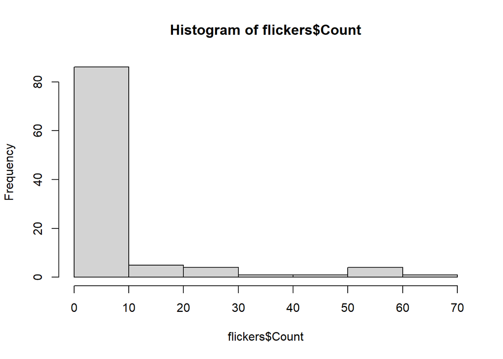

```r
hist(flickers$Count) # excess zeros
```

```r
ZiP1 <- zeroinfl(Count ~ 1 | 1, offset = log(hours), dist = "negbin", data = flickers)
summary(ZiP1)
```

```
##
## Call:
## zeroinfl(formula = Count ~ 1 | 1, data = flickers, offset = log(hours),
##     dist = "negbin")
##
## Pearson residuals:
##     Min      1Q  Median      3Q     Max
## -0.3980 -0.3932 -0.3896 -0.3703  4.1963
##
## Count model coefficients (negbin with log link):
##             Estimate Std. Error z value Pr(>|z|)
## (Intercept)  -1.5615     0.2009  -7.771 7.76e-15 ***
## Log(theta)    0.1100     0.3954   0.278    0.781
##
## Zero-inflation model coefficients (binomial with logit link):
##             Estimate Std. Error z value Pr(>|z|)
## (Intercept)    1.033      0.245   4.215  2.5e-05 ***
## ---
## Signif. codes:  0 '***' 0.001 '**' 0.01 '*' 0.05 '.' 0.1 ' ' 1
##
## Theta = 1.1163
## Number of iterations in BFGS optimization: 7
## Log-likelihood: -157.2 on 3 Df
```

```r
ZiP2 <- zeroinfl(Count ~ Latitude | 1, offset = log(hours), dist = "negbin", data = flickers)
summary(ZiP2)
```

```
##
## Call:
## zeroinfl(formula = Count ~ Latitude | 1, data = flickers, offset = log(hours),
##     dist = "negbin")
##
## Pearson residuals:
##     Min      1Q  Median      3Q     Max
## -0.5115 -0.4968 -0.4223 -0.2140  3.9332
##
## Count model coefficients (negbin with log link):
##             Estimate Std. Error z value Pr(>|z|)
## (Intercept)  36.2123     6.8787   5.264 1.41e-07 ***
## Latitude     -0.8959     0.1627  -5.506 3.67e-08 ***
## Log(theta)    0.9399     0.4046   2.323   0.0202 *
##
## Zero-inflation model coefficients (binomial with logit link):
##             Estimate Std. Error z value Pr(>|z|)
## (Intercept)   0.8865     0.2584    3.43 0.000603 ***
## ---
## Signif. codes:  0 '***' 0.001 '**' 0.01 '*' 0.05 '.' 0.1 ' ' 1
##
## Theta = 2.5598
## Number of iterations in BFGS optimization: 19
## Log-likelihood: -145.1 on 4 Df
```

```r
Anova(ZiP2)
```

```
## Analysis of Deviance Table (Type II tests)
##
## Response: Count
##          Df  Chisq Pr(>Chisq)
## Latitude  1 30.317  3.668e-08 ***
## ---
## Signif. codes:  0 '***' 0.001 '**' 0.01 '*' 0.05 '.' 0.1 ' ' 1
```

```r
ZiP3 <- zeroinfl(Count ~ Latitude | Latitude, offset = log(hours), dist = "negbin", data = flickers)
```

Note that the ‘glmmTMB’ package allows for both zeroinflated mixed models and hurdle mixed models.

```r
ZiP4 <- glmmTMB(Count ~ Latitude, offset = log(hours), ziformula = ~1, family = "nbinom2", data = flickers)
summary(ZiP4)$coefficients
```

```
## $cond
##               Estimate Std. Error   z value     Pr(>|z|)
## (Intercept) 36.2124071  6.8780654  5.264912 1.402567e-07
## Latitude    -0.8959298  0.1626989 -5.506675 3.656741e-08
##
## $zi
##              Estimate Std. Error  z value     Pr(>|z|)
## (Intercept) 0.8864842  0.2584243 3.430344 0.0006028174
##
## $disp
## NULL
```

```r
ZiP5 <- glmmTMB(Count ~ Latitude, offset = log(hours), ziformula = ~., family = "nbinom2", data = flickers)
summary(ZiP5)$coefficients
```

```
## $cond
##               Estimate Std. Error   z value     Pr(>|z|)
## (Intercept) 31.7812147  6.2946235  5.048946 4.442540e-07
## Latitude    -0.7902148  0.1488927 -5.307276 1.112756e-07
##
## $zi
##                Estimate Std. Error   z value   Pr(>|z|)
## (Intercept) -22.3363235  9.9557076 -2.243570 0.02486010
## Latitude      0.5447831  0.2337981  2.330143 0.01979857
##
## $disp
## NULL
```

For hurdle models, the nonzero and zero processes are modelled separately, and therefore, we assume all zeros are true zeros. For the deer data, let’s assume that method for detecting *Elaphostrongylus cervi* parasites in red deer is very accurate and all zeros are true zeros. Here, let’s evaluate whether the probability of infection dependent on sex and the infection intensity is dependent on kidney fat index (KFI).

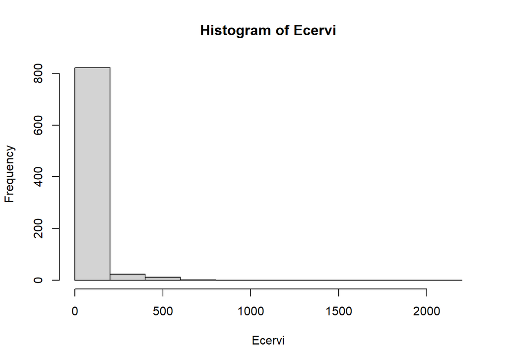

```r
with(deer, hist(Ecervi)) # zero-inflated
```

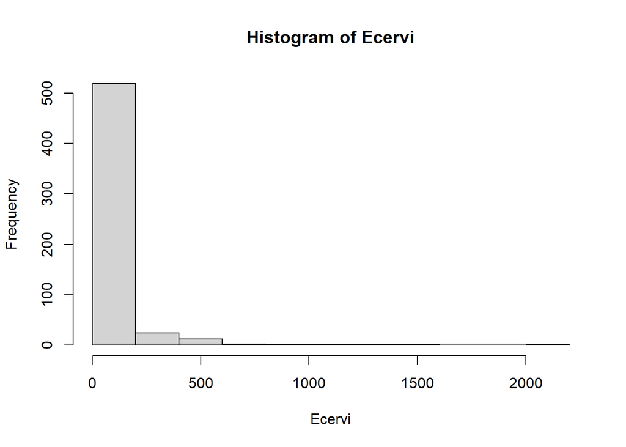

```r
with(subset(deer, P.Ecervi == 1), hist(Ecervi))
```

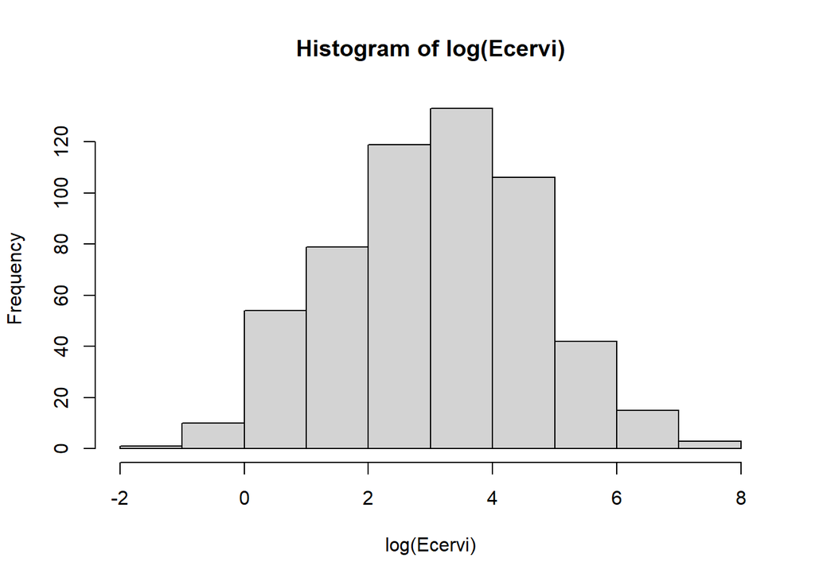

```r
with(subset(deer, P.Ecervi == 1), hist(log(Ecervi)))
```

```r
h_zero <- glm(P.Ecervi ~ Sex, family = binomial, data = deer)
Anova(h_zero)
```

```
## Analysis of Deviance Table (Type II tests)
##
## Response: P.Ecervi
##     LR Chisq Df Pr(>Chisq)
## Sex   11.151  1  0.0008397 ***
## ---
## Signif. codes:  0 '***' 0.001 '**' 0.01 '*' 0.05 '.' 0.1 ' ' 1
```

```r
coef(h_zero)
```

```
## (Intercept)         Sex
##   1.3319519  -0.4826007
```

```r
h_nzero <- glm(log(Ecervi) ~ KFI, family = gaussian, data = subset(deer, P.Ecervi == 1))
Anova(h_nzero)
```

```
## Analysis of Deviance Table (Type II tests)
##
## Response: log(Ecervi)
##     LR Chisq Df Pr(>Chisq)
## KFI   9.4023  1   0.002167 **
## ---
## Signif. codes:  0 '***' 0.001 '**' 0.01 '*' 0.05 '.' 0.1 ' ' 1
```

```r
summary(h_nzero)
```

```
##
## Call:
## glm(formula = log(Ecervi) ~ KFI, family = gaussian, data = subset(deer,
##     P.Ecervi == 1))
##
## Deviance Residuals:
##     Min       1Q   Median       3Q      Max
## -3.3964  -1.1184   0.0061   1.0151   4.2076
##
## Coefficients:
##              Estimate Std. Error t value Pr(>|t|)
## (Intercept)  3.178997   0.113517  28.005  < 2e-16 ***
## KFI         -0.008300   0.002707  -3.066  0.00231 **
## ---
## Signif. codes:  0 '***' 0.001 '**' 0.01 '*' 0.05 '.' 0.1 ' ' 1
##
## (Dispersion parameter for gaussian family taken to be 2.443036)
##
##     Null deviance: 1034.4  on 415  degrees of freedom
## Residual deviance: 1011.4  on 414  degrees of freedom
##   (146 observations deleted due to missingness)
## AIC: 1556.1
##
## Number of Fisher Scoring iterations: 2
```

A Gamma distribution cannot be overdispersed. The glmmTMB package also allows for hurdle models for count data using the “truncated_poisson”

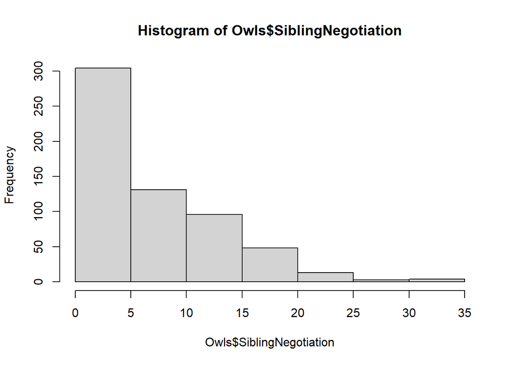

```r
hist(Owls$SiblingNegotiation)
```

```r
#h_mod <- glmmTMB(SiblingNegotiation ~ BroodSize, family = truncated)
```

**Practice example 9**: Similar to the Northern Flickers, the Eastern bluebird data was also collected across New England from the Audubon Christmas bird count. Eastern Bluebirds have breeding grounds in the northern half of the United States, but all year grounds south of Massachusetts down to Texas and exclusive wintering grounds in Texas and northern Mexico.

Using the “bluebird.csv” data, choose whether a zeroinflated or hurdle model of bird counts with an offset of observation hours is more appropriate for these data. Evaluate both latitude on the zero (i.e., probability that it has migrated) and nonzero (i.e., # of all-year resident birds) process parts.

### 5. Mixed models

Here, we evaluated models with fixed effects. Fixed effects are the covariates of interest. Here, we will incorporate models that evaluate both fixed and random effects called “**mixed models**”.

#### Random-coefficient models

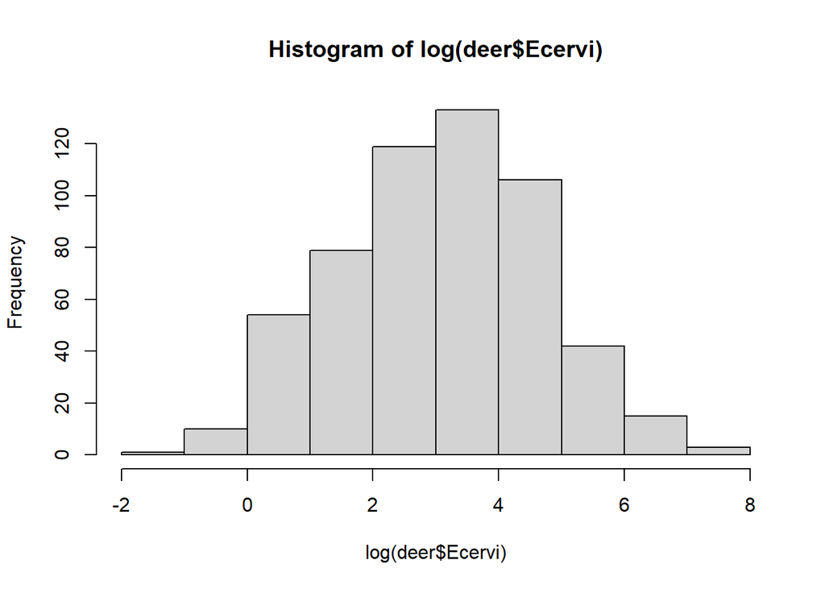

```r
hoppers <- read.csv(here::here("Session 2", "Data", "GrasshopperSong.csv"))
hist(log(deer$Ecervi))
```

```r
#ri1 <- glmmTMB(log(Ecervi) ~ KFI + (1|Farm), family = gaussian, data = subset(deer, !is.na(Ecervi)))
#summary(ri1)
```

```r
#ri2 <- glmmTMB(log(Ecervi) ~ KFI + (0 + KFI |Farm), family = gaussian, data = deer)
#summary(ri2)
```

```r
#ri3 <- glmmTMB(log(Ecervi) ~ KFI + (1|Farm) + (0 + KFI |Farm), family = gaussian, data = deer)
```

```r
#ri4 <- glmmTMB(log(Ecervi) ~ KFI + (0 + KFI |Farm), family = gaussian, data = deer)
```

**Practice example 10:**

#### Nested random effects

**Practice example 11:**

### 6. Intro to simulating data

Normal distribution and how to run linear models in R.

```r
n <- 100000 # sample size
mu <- 600 # mean body mass of male pelegrines
sd <- 30 # SD of body size

sample <- rnorm(n = n, mean = mu, sd = sd)
head(sample) # vector of randomly generated numbers
```

```
## [1] 633.8971 596.6559 592.6534 614.2486 561.1912 593.1531
```

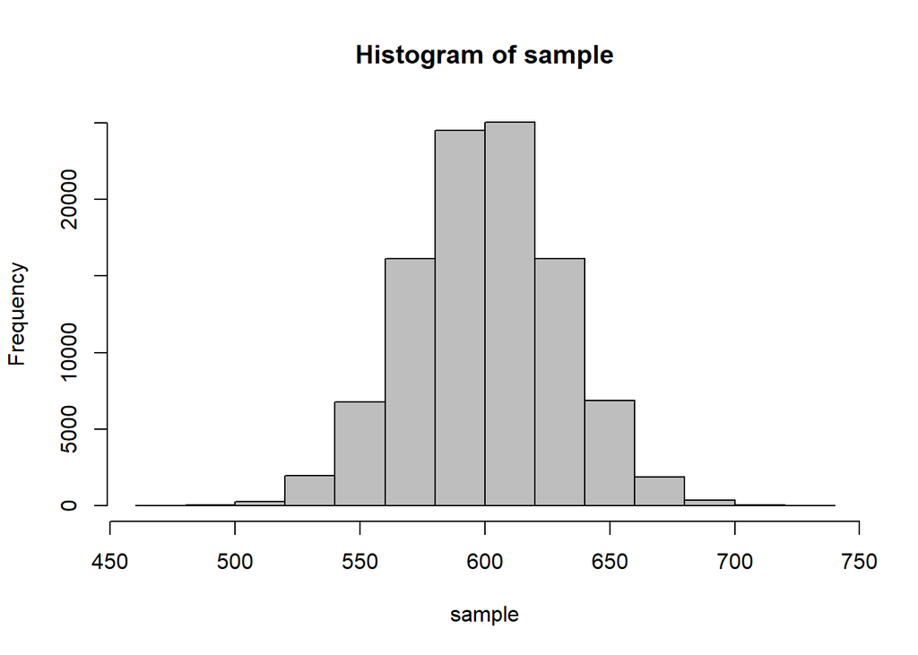

```r
hist(sample, col = "grey")
```

```r
dnorm(x = 650, mean = mu, sd = sd)
```

```
## [1] 0.003315905
```

## Sources

- Bolker, B. (2008) *Ecological models and data in R.* Princeton University Press, Princeton, New Jersey, USA. (https://ms.mcmaster.ca/~bolker/emdbook/)
- Burnham, K. P. and Anderson, D. R. (2002) *Model Selection and Inference: A Practical Information-Theoretic Approach.* Second Edition. Springer, New York, New York, USA.
- Kery, M. (2010) *Introduction to WinBUgS for Ecologists.* Academic Press, Burlinton, Massachusetts, USA.
- White G. C. , and Cooch E. (2005). *Program MARK: A Gentle Introduction.* 4th edn. (http://www.phidot.org/software/mark/docs/book/.)
- Zuur, A.F, E.N. Ieno, and E. Meesters. (2009) *A Beginner’s Guide to R.* Springer, New York, New York, USA.